# Text Analysis (2): Supervised Machine Learning

J381M Week 5 Tutorial - Instructor Version

Instructor: Sungwon Jung

February 12, 2026

# Before We Begin: Setup

## Install Required Packages

Before we start, we need to install some R packages. **Do this ONCE before class:**

```r
# Copy and paste this into your R console:
#install.packages(c(
#  "tidyverse",      # For data manipulation and visualization
#  "tidytext",       # For working with text data
#  "tidymodels",     # For machine learning
#  "textrecipes",
#  "stopwords"# For text preprocessing
#))

# Optional - for Exercise 3 later:
#install.packages("ranger")
```

**Having trouble?** - **Mac users**: You might need to install Xcode tools if prompted - **Windows users**: You might need Rtools - **Everyone**: Try installing one package at a time if you get errors

## Load the Packages

Now let’s load the packages we just installed:

```r
library(tidyverse)
library(tidytext)
library(textrecipes)
library(tidymodels)

cat("Packages loaded!\n")
```

```
## Packages loaded!
```

## Quick Test

Let’s make sure everything is working:

```r
# Create a simple test
test_data <- tibble(
  text = c("I love this", "This is bad", "Pretty good"),
  rating = c(5, 1, 4)
)

# Try to tokenize (split into words)
test_data %>%
  unnest_tokens(word, text) %>%
  head()
```

```
## # A tibble: 6 × 2
##   rating word
##    <dbl> <chr>
## 1      5 i
## 2      5 love
## 3      5 this
## 4      1 this
## 5      1 is
## 6      1 bad
```

```r
cat("\nEverything works!\n")
```

```
##
## Everything works!
```

If you see the table above with words, you’re all set!

**Still having issues?** Ask for help now before we start!

# Part 1: Core ML Principles (10 min)

## What is Supervised Learning?

**Supervised Learning** = Learning from labeled examples

Think of it like learning with flashcards: - **Front**: Input (review text) - **Back**: Correct answer (rating or sentiment) - **Goal**: Learn to predict the back from the front

## Two Main Tasks

### 1. Classification (Predicting Categories)

**Examples:** - Is this review positive or negative? - Is this email spam? - Which topic does this article discuss?

**Output:** Discrete labels (positive, negative, spam, not spam)

### 2. Regression (Predicting Numbers)

**Examples:** - What rating (1-5 stars) will this review give? - How many likes will this post get? - What’s the temperature tomorrow?

**Output:** Continuous values (1.5 stars, 234 likes, 72°F)

## Train/Test Split

**Critical Rule:** Never test on data you trained on!

```
Total Data (100%)
│
├─ Training Set (75%)    ← Model learns here
└─ Test Set (25%)        ← Evaluate here (NEVER touch during training!)
```

**Why?** If you test on training data, you can’t tell if your model actually learned patterns or just memorized answers!

### Dealing with Imbalanced Data

Real-world data is often **imbalanced** - one class appears much more than others.

**Example:** In our Amazon reviews: - Negative reviews: 71% (14,350 reviews) - Positive reviews: 29% (5,820 reviews)

**Problem:** A “dumb” model that always predicts “negative” gets 71% accuracy!

**Solutions:** 1. **Stratified sampling**: Keep same class proportions in train/test - We use `strata = sentiment` in `initial_split()` 2. **Look beyond accuracy**: Use precision, recall, F1-score 3. **Balanced metrics**: Consider performance on BOTH classes

**Today we’ll use stratified sampling + balanced metrics!**

# Part 2: Text as Features

Computers don’t understand words - we need to convert text to numbers.

## The Pipeline

```
"This product is amazing!"
    ↓ Tokenization
["This", "product", "is", "amazing"]
    ↓ Remove Stop Words
["product", "amazing"]
    ↓ Vectorization
[product: 1, amazing: 1, ...]
```

### Key Concepts

**1. Tokenization**: Split text into words

**2. Stop Words**: Common words with little meaning (“the”, “a”, “is”)

**3. TF-IDF**: Weight words by importance - **TF** (Term Frequency): How often word appears in document - **IDF** (Inverse Document Frequency): How rare word is across all documents - **TF-IDF**: Highlights unique, discriminative words

**Example:** - “amazon” appears in every review → low TF-IDF (not useful) - “excellent” appears only in positive reviews → high TF-IDF (very useful!)

# Part 3: Loading and Preparing Data

## Load Dataset

```r
# Load Amazon Reviews
# Make sure the CSV file is in the same folder as this RMD file
# Or update the path below to where your file is located

amazon_reviews_raw <- read_csv(
  "/Users/sungwonjung/Downloads/Amazon_Reviews.csv",  # Change this path if needed
  col_types = cols(
    `Reviewer Name` = col_character(),
    Country = col_character(),
    Rating = col_character(),
    `Review Title` = col_character(),
    `Review Text` = col_character(),
    .default = col_character()
  )
)

cat("Total reviews:", nrow(amazon_reviews_raw), "\n")
```

```
## Total reviews: 21055
```

```r
glimpse(amazon_reviews_raw)
```

```
## Rows: 21,055
## Columns: 9
## $ `Reviewer Name`      <chr> "Eugene ath", "Daniel ohalloran", "p fisher", "Gr…
## $ `Profile Link`       <chr> "/users/66e8185ff1598352d6b3701a", "/users/5d75e4…
## $ Country              <chr> "US", "GB", "GB", "AU", "GB", "US", "US", "US", "…
## $ `Review Count`       <chr> "1 review", "9 reviews", "90 reviews", "5 reviews…
## $ `Review Date`        <chr> "2024-09-16T13:44:26.000Z", "2024-09-16T18:26:46.…
## $ Rating               <chr> "Rated 1 out of 5 stars", "Rated 1 out of 5 stars…
## $ `Review Title`       <chr> "A Store That Doesn't Want to Sell Anything", "Ha…
## $ `Review Text`        <chr> "I registered on the website, tried to order a la…
## $ `Date of Experience` <chr> "September 16, 2024", "September 16, 2024", "Sept…
```

## Clean Data

```r
amazon_reviews_clean <- amazon_reviews_raw %>%
  rename(
    rating_text = Rating,
    review_text = `Review Text`
  ) %>%
  # Extract numeric rating
  mutate(rating = as.numeric(str_extract(rating_text, "\\d+"))) %>%
  # Filter valid data
  filter(
    !is.na(review_text),
    review_text != "",
    !is.na(rating),
    rating >= 1 & rating <= 5
  ) %>%
  # Add features
  mutate(
    word_count = str_count(review_text, "\\w+"),
    sentiment = case_when(
      rating >= 4 ~ "positive",
      rating <= 2 ~ "negative",
      TRUE ~ "neutral"
    )
  )

cat("After cleaning:", nrow(amazon_reviews_clean), "reviews\n")
```

```
## After cleaning: 21055 reviews
```

## Prepare Datasets

```r
# CLASSIFICATION: Binary sentiment (pos vs neg)
amazon_classification <- amazon_reviews_clean %>%
  filter(sentiment != "neutral") %>%
  mutate(sentiment = factor(sentiment, levels = c("negative", "positive"))) %>%
  select(review_text, sentiment, rating, word_count)

# REGRESSION: Predict rating (1-5)
amazon_regression <- amazon_reviews_clean %>%
  select(review_text, rating, sentiment, word_count)

cat("Classification dataset:", nrow(amazon_classification), "reviews\n")
```

```
## Classification dataset: 20170 reviews
```

```r
cat("Regression dataset:", nrow(amazon_regression), "reviews\n")
```

```
## Regression dataset: 21055 reviews
```

## Example Reviews

```r
set.seed(2025)

cat("=== POSITIVE Examples ===\n\n")
```

```
## === POSITIVE Examples ===
```

```r
amazon_classification %>%
  filter(sentiment == "positive") %>%
  slice_sample(n = 2) %>%
  pull(review_text) %>%
  str_trunc(200) %>%
  paste0(1:2, ". ", .) %>%
  cat(sep = "\n\n")
```

```
## 1. Let me down few time but overall great, especially prime deliveries next day or sometimes even same day before 10pm.
##
## 2. Great customer service, whenever there is an issue they resolve it. I have bought many things from Amazon.
```

```r
cat("\n\n=== NEGATIVE Examples ===\n\n")
```

```
##
##
## === NEGATIVE Examples ===
```

```r
amazon_classification %>%
  filter(sentiment == "negative") %>%
  slice_sample(n = 2) %>%
  pull(review_text) %>%
  str_trunc(200) %>%
  paste0(1:2, ". ", .) %>%
  cat(sep = "\n\n")
```

```
## 1. Very bad servicebad experience
##
## 2. Pick up the phone with so loud background noisy; got my information then put me on the ugly to hell music and disappeared for more than 10 min.... such a dirty business and need to cancel the prime...
```

# Part 4: TASK 1 - CLASSIFICATION

Predicting sentiment (positive vs negative)

## Visualize the Data

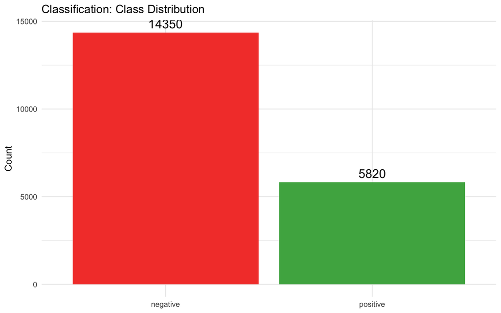

```r
# Class distribution
ggplot(amazon_classification, aes(x = sentiment, fill = sentiment)) +
  geom_bar() +
  geom_text(stat = "count", aes(label = after_stat(count)), vjust = -0.5, size = 5) +
  labs(title = "Classification: Class Distribution",
       x = NULL, y = "Count") +
  scale_fill_manual(values = c("negative" = "#F44336", "positive" = "#4CAF50")) +
  theme_minimal() +
  theme(legend.position = "none")
```

```r
# Check class balance
class_dist <- amazon_classification %>%
  count(sentiment) %>%
  mutate(pct = round(n/sum(n)*100, 1))

cat("\n=== Class Distribution ===\n")
```

```
##
## === Class Distribution ===
```

```r
print(class_dist)
```

```
## # A tibble: 2 × 3
##   sentiment     n   pct
##   <fct>     <int> <dbl>
## 1 negative  14350  71.1
## 2 positive   5820  28.9
```

```r
neg_count <- class_dist %>% filter(sentiment == "negative") %>% pull(n)
pos_count <- class_dist %>% filter(sentiment == "positive") %>% pull(n)
imbalance_ratio <- round(neg_count / pos_count, 1)

cat("\nCLASS IMBALANCE DETECTED!\n")
```

```
##
## CLASS IMBALANCE DETECTED!
```

```r
cat("Ratio:", imbalance_ratio, ": 1 (negative:positive)\n")
```

```
## Ratio: 2.5 : 1 (negative:positive)
```

```r
cat("Negative:", round(class_dist$pct[1], 1), "% | Positive:", round(class_dist$pct[2], 1), "%\n\n")
```

```
## Negative: 71.1 % | Positive: 28.9 %
```

```r
cat("Why this matters:\n")
```

```
## Why this matters:
```

```r
cat("- A 'dumb' model that always predicts 'negative' would get",
    round(class_dist$pct[1], 1), "% accuracy!\n")
```

```
## - A 'dumb' model that always predicts 'negative' would get 71.1 % accuracy!
```

```r
cat("- Our model needs to do BETTER than this baseline\n")
```

```
## - Our model needs to do BETTER than this baseline
```

```r
cat("- We'll use stratified sampling to maintain balance in train/test splits\n\n")
```

```
## - We'll use stratified sampling to maintain balance in train/test splits
```

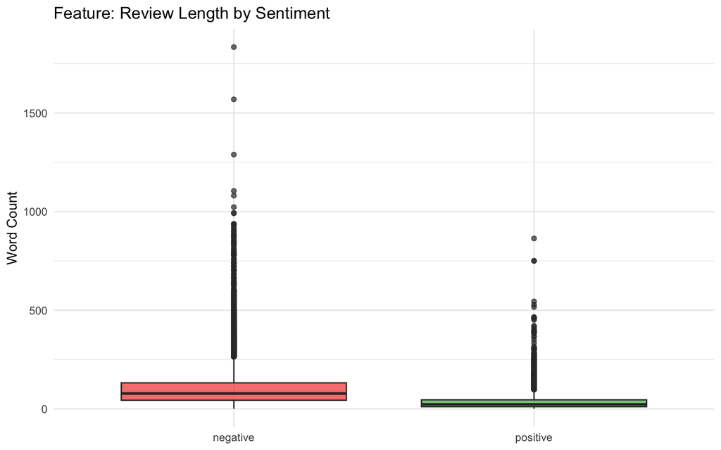

```r
# Feature analysis: Review length by sentiment
ggplot(amazon_classification, aes(x = sentiment, y = word_count, fill = sentiment)) +
  geom_boxplot(alpha = 0.7) +
  labs(title = "Feature: Review Length by Sentiment",
       x = NULL, y = "Word Count") +
  scale_fill_manual(values = c("negative" = "#F44336", "positive" = "#4CAF50")) +
  theme_minimal() +
  theme(legend.position = "none")
```

## Split Data

```r
set.seed(2025)

# 75-25 split with stratification
split_class <- initial_split(amazon_classification, prop = 0.75, strata = sentiment)
train_class <- training(split_class)
test_class <- testing(split_class)

cat("Training:", nrow(train_class), "| Test:", nrow(test_class), "\n")
```

```
## Training: 15127 | Test: 5043
```

```r
train_class %>% count(sentiment)
```

```
## # A tibble: 2 × 2
##   sentiment     n
##   <fct>     <int>
## 1 negative  10762
## 2 positive   4365
```

## Step 1: Set Up Text Preprocessing

```r
# Define how to convert text to numbers
preprocess_class <- recipe(sentiment ~ review_text, data = train_class) %>%
  step_tokenize(review_text) %>%              # Split into words
  step_stopwords(review_text) %>%             # Remove "the", "a", etc.
  step_tokenfilter(review_text, max_tokens = 1000) %>%  # Keep top 1000 words
  step_tfidf(review_text)                     # Calculate word importance

preprocess_class
```

[output not shown]

## Step 2: Choose Model

```r
# Use Logistic Regression
model_class <- logistic_reg() %>%
  set_engine("glm") %>%
  set_mode("classification")
```

## Step 3: Train the Model

```r
# Combine preprocessing + model
pipeline_class <- workflow() %>%
  add_recipe(preprocess_class) %>%
  add_model(model_class)

# Train
fit_class <- pipeline_class %>%
  fit(data = train_class)

cat("Classification model trained!\n")
```

```
## Classification model trained!
```

## Step 4: Make Predictions

```r
# Predict on test set
pred_class <- fit_class %>%
  predict(new_data = test_class) %>%
  bind_cols(test_class)

# View some predictions
pred_class %>%
  select(review_text, sentiment, .pred_class) %>%
  slice_sample(n = 10)
```

```
## # A tibble: 10 × 3
##    review_text                                             sentiment .pred_class
##    <chr>                                                   <fct>     <fct>
##  1 Review text not found                                   negative  positive
##  2 Very poor ruined my birthday gift poor poor poor scamm… negative  negative
##  3 I have been a seller on Amazon for 6 months and my sto… negative  negative
##  4 The customer service representative was an absolute je… negative  negative
##  5 Garbage DeliveryI ordered an AC, But it never arrived,… negative  negative
##  6 I've been shopping with Amazon for years, and it's a g… positive  positive
##  7 Customer service representative spoke with very strong… negative  negative
##  8 I love Amazon when i need anything i can find it on th… positive  positive
##  9 Horrendous costumers service  still  waiting  my refun… negative  negative
## 10 Stupid Amazon App blocks you from reporting missing it… negative  negative
```

## Step 5: Evaluate Performance

```r
# Confusion Matrix
conf_mat_class <- pred_class %>%
  conf_mat(truth = sentiment, estimate = .pred_class)

print(conf_mat_class)
```

```
##           Truth
## Prediction negative positive
##   negative     3361      188
##   positive      227     1267
```

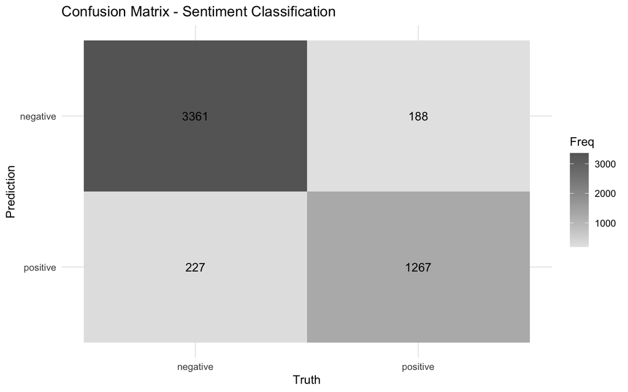

```r
autoplot(conf_mat_class, type = "heatmap") +
  labs(title = "Confusion Matrix - Sentiment Classification") +
  theme_minimal()
```

```r
# Basic metrics
metrics_class <- pred_class %>%
  metrics(truth = sentiment, estimate = .pred_class)

print(metrics_class)
```

```
## # A tibble: 2 × 3
##   .metric  .estimator .estimate
##   <chr>    <chr>          <dbl>
## 1 accuracy binary         0.918
## 2 kap      binary         0.801
```

```r
accuracy <- metrics_class %>% filter(.metric == "accuracy") %>% pull(.estimate)
cat("\nOverall Accuracy:", round(accuracy * 100, 2), "%\n")
```

```
##
## Overall Accuracy: 91.77 %
```

```r
# Compare to baseline
baseline_accuracy <- neg_count / (neg_count + pos_count)
cat("\n=== Baseline Comparison ===\n")
```

```
##
## === Baseline Comparison ===
```

```r
cat("Baseline (always predict negative):", round(baseline_accuracy * 100, 2), "%\n")
```

```
## Baseline (always predict negative): 71.15 %
```

```r
cat("Our model:", round(accuracy * 100, 2), "%\n")
```

```
## Our model: 91.77 %
```

```r
cat("Improvement:", round((accuracy - baseline_accuracy) * 100, 2), "percentage points\n")
```

```
## Improvement: 20.63 percentage points
```

```r
if (accuracy > baseline_accuracy + 0.10) {
  cat("\nModel is significantly better than baseline!\n")
} else {
  cat("\nModel barely beats the baseline - might need improvement\n")
}
```

```
##
## Model is significantly better than baseline!
```

```r
# Class-specific metrics (important for imbalanced data!)
cat("\n=== Class-Specific Performance ===\n")
```

```
##
## === Class-Specific Performance ===
```

```r
class_metrics <- pred_class %>%
  precision(truth = sentiment, estimate = .pred_class) %>%
  bind_rows(pred_class %>% recall(truth = sentiment, estimate = .pred_class)) %>%
  bind_rows(pred_class %>% f_meas(truth = sentiment, estimate = .pred_class))

print(class_metrics)
```

```
## # A tibble: 3 × 3
##   .metric   .estimator .estimate
##   <chr>     <chr>          <dbl>
## 1 precision binary         0.947
## 2 recall    binary         0.937
## 3 f_meas    binary         0.942
```

```r
cat("\nWhy these metrics matter with imbalanced data:\n")
```

```
##
## Why these metrics matter with imbalanced data:
```

```r
cat("- Precision: Of predictions we made, how many were correct?\n")
```

```
## - Precision: Of predictions we made, how many were correct?
```

```r
cat("- Recall: Of actual cases, how many did we catch?\n")
```

```
## - Recall: Of actual cases, how many did we catch?
```

```r
cat("- F1: Harmonic mean of precision and recall\n")
```

```
## - F1: Harmonic mean of precision and recall
```

## Step 6: Feature Importance

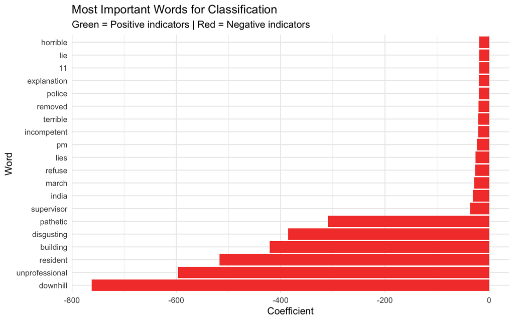

```r
# Extract coefficients
coefs <- fit_class %>%
  extract_fit_parsnip() %>%
  tidy() %>%
  filter(term != "(Intercept)") %>%
  mutate(
    term = str_remove(term, "tfidf_review_text_"),
    abs_estimate = abs(estimate)
  )

# Top 20 words
top20 <- coefs %>% slice_max(abs_estimate, n = 20)

ggplot(top20, aes(x = reorder(term, estimate), y = estimate, fill = estimate > 0)) +
  geom_col() +
  coord_flip() +
  labs(title = "Most Important Words for Classification",
       subtitle = "Green = Positive indicators | Red = Negative indicators",
       x = "Word", y = "Coefficient") +
  scale_fill_manual(values = c("TRUE" = "#4CAF50", "FALSE" = "#F44336")) +
  theme_minimal() +
  theme(legend.position = "none")
```

```r
cat("\n=== Top Positive Words ===\n")
```

```
##
## === Top Positive Words ===
```

```r
coefs %>% slice_max(estimate, n = 5) %>% select(term, estimate) %>% print()
```

```
## # A tibble: 5 × 2
##   term      estimate
##   <chr>        <dbl>
## 1 excellent     17.0
## 2 quickly       16.0
## 3 questions     14.4
## 4 love          14.1
## 5 great         13.0
```

```r
cat("\n=== Top Negative Words ===\n")
```

```
##
## === Top Negative Words ===
```

```r
coefs %>% slice_min(estimate, n = 5) %>% select(term, estimate) %>% print()
```

```
## # A tibble: 5 × 2
##   term           estimate
##   <chr>             <dbl>
## 1 downhill          -762.
## 2 unprofessional    -597.
## 3 resident          -517.
## 4 building          -421.
## 5 disgusting        -386.
```

# Part 5: TASK 2 - REGRESSION

Predicting rating (1-5 stars)

## Visualize the Data

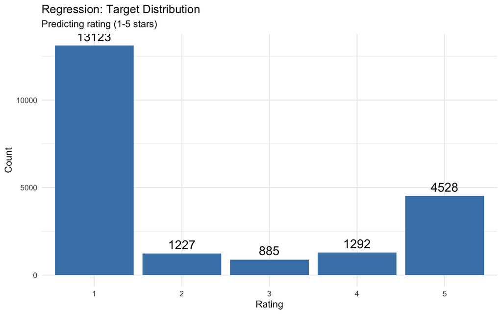

```r
# Target distribution
ggplot(amazon_regression, aes(x = factor(rating))) +
  geom_bar(fill = "steelblue") +
  geom_text(stat = "count", aes(label = after_stat(count)), vjust = -0.5, size = 5) +
  labs(title = "Regression: Target Distribution",
       subtitle = "Predicting rating (1-5 stars)",
       x = "Rating", y = "Count") +
  theme_minimal()
```

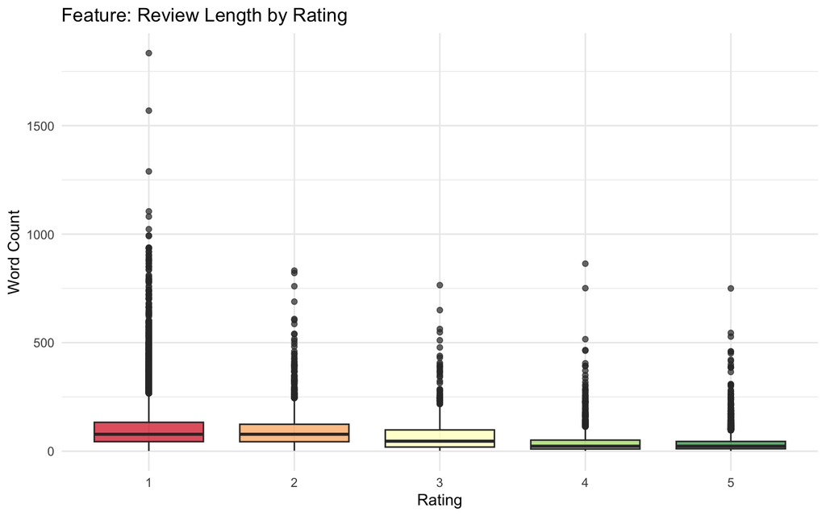

```r
# Feature analysis: Review length by rating
ggplot(amazon_regression, aes(x = factor(rating), y = word_count, fill = factor(rating))) +
  geom_boxplot(alpha = 0.7) +
  labs(title = "Feature: Review Length by Rating",
       x = "Rating", y = "Word Count") +
  scale_fill_brewer(palette = "RdYlGn", direction = 1) +
  theme_minimal() +
  theme(legend.position = "none")
```

## Split Data

```r
set.seed(2025)

split_reg <- initial_split(amazon_regression, prop = 0.75)
train_reg <- training(split_reg)
test_reg <- testing(split_reg)

cat("Training:", nrow(train_reg), "| Test:", nrow(test_reg), "\n")
```

```
## Training: 15791 | Test: 5264
```

## Step 1: Set Up Text Preprocessing

```r
# Same preprocessing as classification
preprocess_reg <- recipe(rating ~ review_text, data = train_reg) %>%
  step_tokenize(review_text) %>%
  step_stopwords(review_text) %>%
  step_tokenfilter(review_text, max_tokens = 1000) %>%
  step_tfidf(review_text)
```

## Step 2: Choose Model

```r
# Use Linear Regression
model_reg <- linear_reg() %>%
  set_engine("lm") %>%
  set_mode("regression")
```

## Step 3: Train the Model

```r
# Combine preprocessing + model
pipeline_reg <- workflow() %>%
  add_recipe(preprocess_reg) %>%
  add_model(model_reg)

# Train
fit_reg <- pipeline_reg %>%
  fit(data = train_reg)

cat("Regression model trained!\n")
```

```
## Regression model trained!
```

## Step 4: Make Predictions

```r
# Predict
pred_reg <- fit_reg %>%
  predict(new_data = test_reg) %>%
  bind_cols(test_reg) %>%
  mutate(error = rating - .pred)

# View some predictions
pred_reg %>%
  select(rating, .pred, review_text) %>%
  mutate(review_text = str_trunc(review_text, 80)) %>%
  slice_sample(n = 10)
```

```
## # A tibble: 10 × 3
##    rating  .pred review_text
##     <dbl>  <dbl> <chr>
##  1      5  5.52  great service.
##  2      1  1.66  I've been a customer for years and spend literal thousands of …
##  3      5  3.97  With a busy store and growing business it helps to be able to …
##  4      2  2.74  I find it amazing that Amazon brags about their one day delive…
##  5      5  4.16  I do a lot of business with Amazon, I have never been disappoi…
##  6      1 -0.364 wau, Really ,, customer support SUCKS , worst , they barely sp…
##  7      5  2.74  After a horrible experience with Walmart with a book order . I…
##  8      1  1.11  Okay so my problem with amazon originally started as my fault,…
##  9      1  2.06  I need support on making an order.  There is absolutely no way…
## 10      1  0.456 Charged me back after the refunding me for my return. Amazon i…
```

## Step 5: Evaluate Performance

```r
# Metrics
metrics_reg <- pred_reg %>%
  metrics(truth = rating, estimate = .pred)

print(metrics_reg)
```

```
## # A tibble: 3 × 3
##   .metric .estimator .estimate
##   <chr>   <chr>          <dbl>
## 1 rmse    standard       1.08
## 2 rsq     standard       0.587
## 3 mae     standard       0.826
```

```r
rmse <- metrics_reg %>% filter(.metric == "rmse") %>% pull(.estimate)
rsq <- metrics_reg %>% filter(.metric == "rsq") %>% pull(.estimate)

cat("\nRMSE:", round(rmse, 3), "stars\n")
```

```
##
## RMSE: 1.084 stars
```

```r
cat("R²:", round(rsq, 3), "\n")
```

```
## R²: 0.587
```

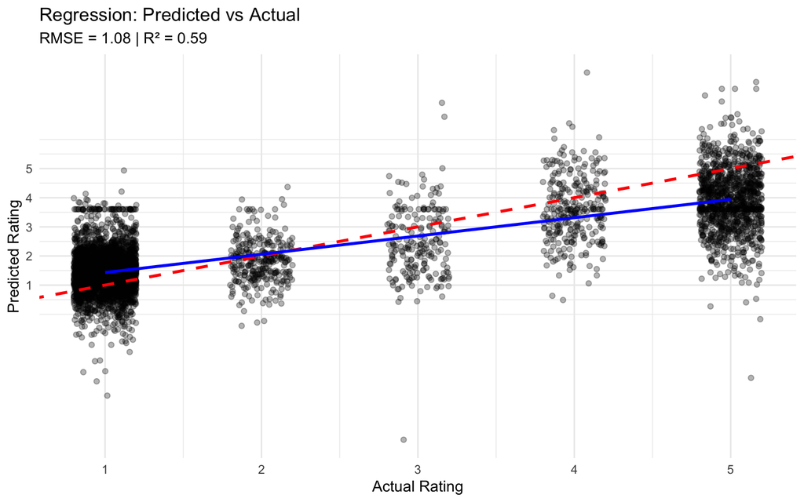

```r
# Predicted vs Actual
ggplot(pred_reg, aes(x = rating, y = .pred)) +
  geom_jitter(alpha = 0.3, width = 0.2) +
  geom_abline(slope = 1, intercept = 0, color = "red", linetype = "dashed", size = 1) +
  geom_smooth(method = "lm", se = FALSE, color = "blue") +
  labs(title = "Regression: Predicted vs Actual",
       subtitle = paste0("RMSE = ", round(rmse, 2), " | R² = ", round(rsq, 2)),
       x = "Actual Rating", y = "Predicted Rating") +
  scale_x_continuous(breaks = 1:5) +
  scale_y_continuous(breaks = 1:5) +
  theme_minimal()
```

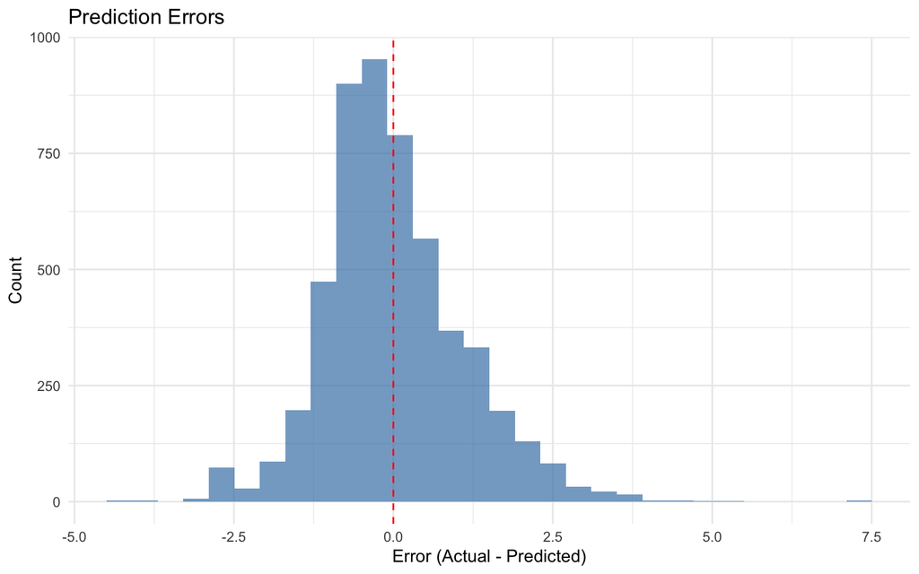

```r
# Error distribution
ggplot(pred_reg, aes(x = error)) +
  geom_histogram(bins = 30, fill = "steelblue", alpha = 0.7) +
  geom_vline(xintercept = 0, color = "red", linetype = "dashed") +
  labs(title = "Prediction Errors",
       x = "Error (Actual - Predicted)", y = "Count") +
  theme_minimal()
```

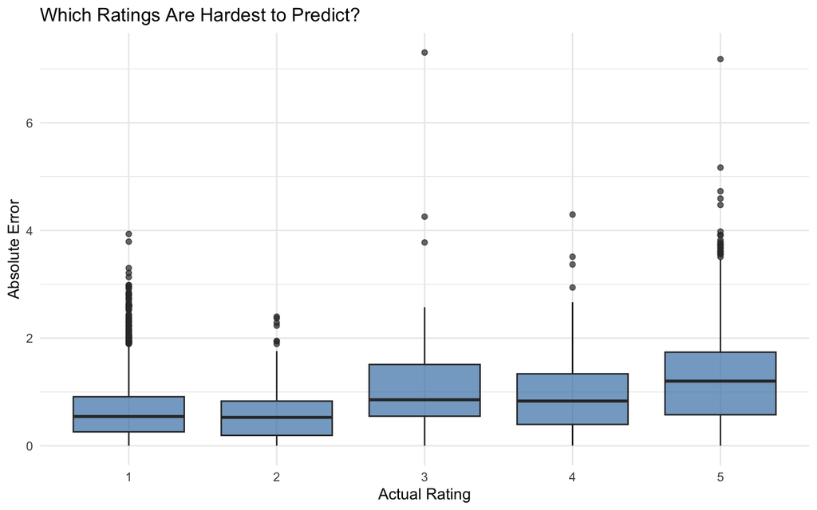

```r
# Errors by rating
ggplot(pred_reg, aes(x = factor(rating), y = abs(error))) +
  geom_boxplot(fill = "steelblue", alpha = 0.7) +
  labs(title = "Which Ratings Are Hardest to Predict?",
       x = "Actual Rating", y = "Absolute Error") +
  theme_minimal()
```

## Step 6: Feature Importance

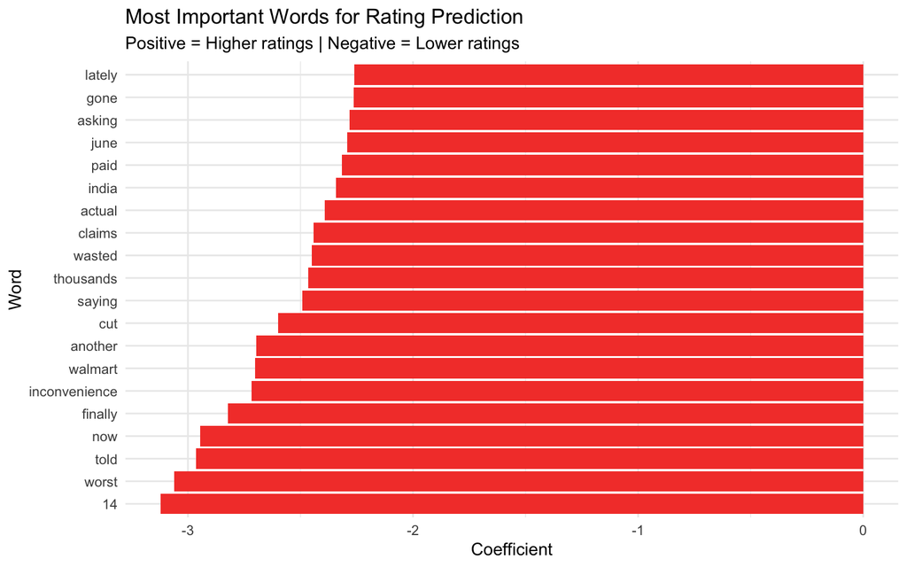

```r
coefs_reg <- fit_reg %>%
  extract_fit_parsnip() %>%
  tidy() %>%
  filter(term != "(Intercept)") %>%
  mutate(
    term = str_remove(term, "tfidf_review_text_"),
    abs_estimate = abs(estimate)
  )

top20_reg <- coefs_reg %>% slice_max(abs_estimate, n = 20)

ggplot(top20_reg, aes(x = reorder(term, estimate), y = estimate, fill = estimate > 0)) +
  geom_col() +
  coord_flip() +
  labs(title = "Most Important Words for Rating Prediction",
       subtitle = "Positive = Higher ratings | Negative = Lower ratings",
       x = "Word", y = "Coefficient") +
  scale_fill_manual(values = c("FALSE" = "#F44336", "TRUE" = "#4CAF50")) +
  theme_minimal() +
  theme(legend.position = "none")
```

# Part 6: Comparing Classification vs Regression

```r
cat("============================================\n")
cat("CLASSIFICATION vs REGRESSION\n")
```

```
## CLASSIFICATION vs REGRESSION
```

```r
cat("============================================\n\n")
cat("CLASSIFICATION (Binary: Positive vs Negative)\n")
```

```
## CLASSIFICATION (Binary: Positive vs Negative)
```

```r
cat("- Task: Predict category\n")
```

```
## - Task: Predict category
```

```r
cat("- Accuracy:", round(accuracy * 100, 2), "%\n")
```

```
## - Accuracy: 91.77 %
```

```r
cat("- Use when: Clear binary/multi-class decisions\n")
```

```
## - Use when: Clear binary/multi-class decisions
```

```r
cat("- Examples: Spam filter, sentiment analysis, topic classification\n\n")
```

```
## - Examples: Spam filter, sentiment analysis, topic classification
```

```r
cat("REGRESSION (Continuous: 1-5 stars)\n")
```

```
## REGRESSION (Continuous: 1-5 stars)
```

```r
cat("- Task: Predict numeric value\n")
```

```
## - Task: Predict numeric value
```

```r
cat("- RMSE:", round(rmse, 3), "stars | R²:", round(rsq, 3), "\n")
```

```
## - RMSE: 1.084 stars | R²: 0.587
```

```r
cat("- Use when: Predicting quantities or scores\n")
```

```
## - Use when: Predicting quantities or scores
```

```r
cat("- Examples: Price prediction, rating prediction, demand forecasting\n\n")
```

```
## - Examples: Price prediction, rating prediction, demand forecasting
```

```r
cat("Key Differences:\n")
```

```
## Key Differences:
```

```r
cat("1. Output: Category vs Number\n")
```

```
## 1. Output: Category vs Number
```

```r
cat("2. Metrics: Accuracy/F1 vs RMSE/R²\n")
```

```
## 2. Metrics: Accuracy/F1 vs RMSE/R²
```

```r
cat("3. Model: Logistic Regression vs Linear Regression\n")
```

```
## 3. Model: Logistic Regression vs Linear Regression
```

```r
cat("4. Interpretation: Probability of class vs Expected value\n")
```

```
## 4. Interpretation: Probability of class vs Expected value
```

# Wrap-up

## Key Takeaways

- **Supervised Learning**: Learn from labeled examples
- **Classification**: Predict categories (positive/negative)
- **Regression**: Predict numbers (1-5 stars)
- **Text Preprocessing**: Tokenize → Remove stop words → TF-IDF
- **Evaluation**: Accuracy for classification, RMSE for regression
- **Feature Importance**: Which words matter most?
- **Class Imbalance**: Real data is often imbalanced - use stratified sampling and balanced metrics

## Next Steps

- Try with your own text data
- Experiment with different models
- Learn about cross-validation
- Explore deep learning for NLP

## Resources

- [Tidymodels](https://www.tidymodels.org/)
- [Text Mining with R](https://www.tidytextmining.com/)
- [Supervised ML for Text](https://smltar.com/)

*Tutorial by Sungwon Jung, J381M 2026*